# Step2. Null distributions

In this vignette we use Seurat v5 to create a Seurat object and generate permutation matrices needed for STEAM.

We show how to generate the permutation matrices needed to use STEAM. Using a high number of permutations can be time consuming and we offer an option to utilize multiple local cores running in parallel to enable the permutation matrices generation to be used on a local computer. We recommend to start with 1,000 permutation to get a first impression of the trait enrichment patterns in your data, and then use 10,000 permutations for final results.

# 1 Loading libraries

Load libraries.

```r
library(Seurat)
library(hdf5r)
library(ggplot2)
library(dplyr)
library(MASS)
library(future)
library(parallel)
library(steam)
```

# 2 Load data

Load Seurat object.

```r
se <- readRDS(file = "data/human_brain_snRNAseq/se_250_cells_filtered_Metacell_normalized.rds")
se
```

```
## An object of class Seurat
## 42584 features across 715 samples within 2 assays
## Active assay: SCT (21292 features, 3000 variable features)
##  3 layers present: counts, data, scale.data
##  1 other assay present: RNA
```

Visually inspect that the cluster annotations are correct.

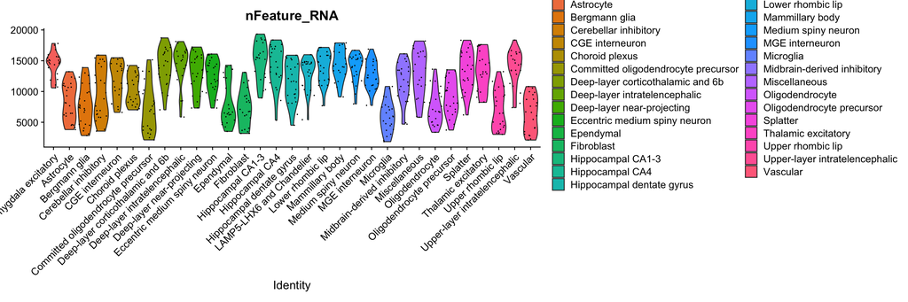

```r
VlnPlot(se, features = c("nFeature_RNA"), ncol = 1, group.by = "supercluster_term")
```

# 3 Generate permutation matrix

IMPORTANT: Please note that the permutation function uses R’s random number generator when selecting random genes to be included in the gene lists used for the null distribution and my differ slightly between different R versions. For reproducibility, always keep track of the R version in which the permutation matrix was generated.

In this section we generate permutation matrices that are used as null distributions to calculate the permutation p-values in other vignettes. As this can be time consuming, it is advisable to e.g., run on a high performance computer cluster if available, or use the option below to run on multiple cores of your local computer. We recommend to start with 1,000 permutation to get a first impression of the trait enrichment patterns in your data. This will normally take between 2 to 15 min per matrix depending on the dataset, gene list length and number of cluster. For final results we strongly recommend to use 10,000 permutations for robust results. Please note that the permutation matrices must be run on the same Seurat object (method of creation and filtering) as that of the STEAM analysis, otherwise the statistical assumptions will not be valid.

```r
# Run sequentially
perm.mat <- generate_permutation_matrix(se, gnum = 50, permutation_nr = 1000, cluster_anno = "supercluster_term")
perm.mat[1:5,1:5]
```

Save the permutation matrix. It is recommended to save as .rds file for easy loading and use.

```r
saveRDS(perm.mat, file = "data/human_brain_snRNAseq/permutation_matrices/perm.mat_p1000_g50.rds")
write.matrix(perm.mat, file=paste0("data/human_brain_snRNAseq/permutation_matrices/perm.mat_p1000_g50.csv"), sep = ";")
```

# 4 Generate permutation matrix using multiple cores

IMPORTANT: Please note that when running multiple processes in parallel the random seed is different. To ensure reproducibility of results, we recommend that you pick one method for your analysis when generating permutation matrices and describe which one in your methods section. When using multiple cores, specify the number of workers selected.

Using multiple core can speed up the generation of permutation matrices considerably. Start by checking how many cores are available on your local computer. Don’t use all cores unless you know your system can handle it.

```r
detectCores() # Detect number of available cores/workers (logical threads)
```

```
## [1] 11
```

In this case we have 11 available workers. To empirically investigate what would run fastest on your computer, we recommend testing several different number of workers using a gene list of 50 genes and 100 permutations.

```r
perm.mat.par <- generate_permutation_matrix(se, gnum = 50, permutation_nr = 100, cluster_anno = "supercluster_term", workers = 7)
```

```
##    user  system elapsed
##   6.469   4.195  17.788
```

```r
perm.mat.par <- generate_permutation_matrix(se, gnum = 50, permutation_nr = 100, cluster_anno = "supercluster_term", workers = 5)
```

```
##    user  system elapsed
##   3.709   3.461  20.362
```

```r
perm.mat.par <- generate_permutation_matrix(se, gnum = 50, permutation_nr = 100, cluster_anno = "supercluster_term", workers = 3)
```

```
##    user  system elapsed
##   1.248   1.558   9.932
```

In this case, we select workers = 3 to generate our permutation matrix.

```r
perm.mat.par <- generate_permutation_matrix(se, gnum = 50, permutation_nr = 10000, cluster_anno = "supercluster_term", workers = 3)
```

```
##    user  system elapsed
##   7.259   0.800 299.206
```

```r
perm.mat.par[1:5,1:5]
```

```
##          Amygdala excitatory   Astrocyte Bergmann glia Cerebellar inhibitory
## Perm_nr1         -0.02221994 -0.02121103   -0.05978827           0.010421139
## Perm_nr2         -0.04722349  0.10191393    0.10423341           0.008504910
## Perm_nr3         -0.03783254 -0.04946540   -0.04627780           0.021161466
## Perm_nr4          0.04210212  0.03261598    0.01009194          -0.005773722
## Perm_nr5          0.02043341 -0.04889645   -0.02980665          -0.035897451
##          CGE interneuron
## Perm_nr1    -0.030625621
## Perm_nr2     0.017654574
## Perm_nr3     0.040846224
## Perm_nr4    -0.007470271
## Perm_nr5    -0.096566175
```

Save the permutation matrix. It is recommended to save as .rds file for easy loading and use.

```r
saveRDS(perm.mat.par, file = "data/human_brain_snRNAseq/permutation_matrices/perm.mat.par_p10000_g50.rds")
write.matrix(perm.mat.par, file=paste0("data/human_brain_snRNAseq/permutation_matrices/perm.mat.par_p10000_g50.csv"), sep = ";")
```